# A1 - Preprocés de dades

Xavier Maltas Tarridas

Octubre 2022

# 1 Càrrega de l’arxiu

En primer lloc, realitzem la càrrega de l’arxiu que conté el conjunt de dades a analitzar.

```r
df.raw <- read.csv("gpa_row.csv", sep=",")
```

Un cop disposem del dataset carregat, elaborem un breu estudi de les dades d’entrada obtenint les dimensions del conjunt, l’estructura i contingut.

```r
print(paste("Dataset contains", nrow(df.raw), "registers"))
```

```
## [1] "Dataset contains 4137 registers"
```

La primera instrucció ens permet observar que disposem d’un total de 4137 registres.

```r
dim(df.raw)
```

```
## [1] 4137   10
```

```r
str(df.raw)
```

```
## 'data.frame':    4137 obs. of  10 variables:
##  $ sat    : int  920 1170 810 940 1180 980 880 980 1240 1230 ...
##  $ tothrs : chr  "43h" "18h" "14h" "40h" ...
##  $ hsize  : chr  "0.1" "9.3999996" "1.1900001" "5.71" ...
##  $ hsrank : int  4 191 42 252 86 41 161 101 161 3 ...
##  $ hsperc : num  40 20.3 35.3 44.1 40.2 ...
##  $ colgpa : num  2.04 4 1.78 2.42 2.61 ...
##  $ athlete: chr  "TRUE" "FALSE" "TRUE" "FALSE" ...
##  $ female : logi  TRUE FALSE FALSE FALSE FALSE TRUE ...
##  $ white  : chr  "FALSE" "TRUE" "TRUE" "TRUE" ...
##  $ black  : chr  "FALSE" "FALSE" "FALSE" "FALSE" ...
```

```r
head(df.raw)
```

```
##    sat tothrs     hsize hsrank   hsperc colgpa athlete female white black
## 1  920    43h       0.1      4 40.00000   2.04    TRUE   TRUE FALSE FALSE
## 2 1170    18h 9.3999996    191 20.31915   4.00   FALSE  FALSE  TRUE FALSE
## 3  810    14h 1.1900001     42 35.29412   1.78    TRUE  FALSE  TRUE FALSE
## 4  940    40h      5.71    252 44.13310   2.42   FALSE  FALSE  TRUE FALSE
## 5 1180    18h 2.1400001     86 40.18692   2.61   FALSE  FALSE  TRUE FALSE
## 6  980   114h 2.6800001     41 15.29851   3.03   FALSE   TRUE  TRUE FALSE
```

```r
summary(df.raw)
```

```
##       sat          tothrs             hsize               hsrank
##  Min.   : 470   Length:4137        Length:4137        Min.   :  1.00
##  1st Qu.: 940   Class :character   Class :character   1st Qu.: 11.00
##  Median :1030   Mode  :character   Mode  :character   Median : 30.00
##  Mean   :1030                                         Mean   : 52.83
##  3rd Qu.:1120                                         3rd Qu.: 70.00
##  Max.   :1540                                         Max.   :634.00
##
##      hsperc            colgpa        athlete            female
##  Min.   : 0.1667   Min.   :0.000   Length:4137        Mode :logical
##  1st Qu.: 6.4328   1st Qu.:2.210   Class :character   FALSE:2277
##  Median :14.5963   Median :2.660   Mode  :character   TRUE :1860
##  Mean   :19.2406   Mean   :2.655
##  3rd Qu.:27.7108   3rd Qu.:3.120
##  Max.   :92.0000   Max.   :4.000
##                    NA's   :41
##     white              black
##  Length:4137        Length:4137
##  Class :character   Class :character
##  Mode  :character   Mode  :character
##
##
##
##
```

```r
sapply(df.raw,class)
```

```
##         sat      tothrs       hsize      hsrank      hsperc      colgpa
##   "integer" "character" "character"   "integer"   "numeric"   "numeric"
##     athlete      female       white       black
## "character"   "logical" "character" "character"
```

Finalment, observarem que disponem de registres amb valors indefinits a l’atribut *‘colgpa’*. Generem un DataFrame independent que conté tots els registres amb valors indefinits.

```r
colSums(is.na(df.raw))
```

```
##     sat  tothrs   hsize  hsrank  hsperc  colgpa athlete  female   white   black
##       0       0       0       0       0      41       0       0       0       0
```

```r
row.has.na <- apply(df.raw, 1, function(x){any(is.na(x))})
df.with.na <- df.raw[row.has.na,]
#df.with.na
```

# 2 Normalització de les variables qualitatives

Com hem comentat en l’apartat anterior, la interpretació del tipus de les dades segons R és errònia. En aquest apartat, realitzarem la transformació corresponent de les variables qualitatives del nostre conjunt de dades. Aquestes variables són: *athlete*, *female*, *white* i *black*.

Prèviament, realitzarem una còpia del dataset original, i sobre aquest segon aplicarem totes les transformacions de normalització.

```r
## Duplicate df to do the cleaning tasks
df.clean <- df.raw
```

## 2.1 Athlete

El tipus de la variable *athlete* és *character*. A la vegada, podem veure que els valors únics d’aquest atribut, són més dels esperats. És per aquest motiu, que, en primer lloc, haurem de modificar aquests valors per tal de només tenir *‘TRUE’* i *‘FALSE’*, i finalment codificar les variables com a tipus *‘factor’*.

```r
typeof(df.clean$athlete)
```

```
## [1] "character"
```

```r
unique(df.clean$athlete)
```

```
## [1] "TRUE"  "FALSE" "false" "true"
```

```r
#Revalue to unique
df.clean$athlete <- revalue (x = df.clean$athlete, c("true"="TRUE", "false"="FALSE"))
unique(df.clean$athlete)
```

```
## [1] "TRUE"  "FALSE"
```

Un cop disposem de valors únics, realitzarem la transformació cap a valors de tipus *‘logical’* i per acabar, codificarem la variable categòrica com a tipus *‘factor’* tal com indica l’enunciat.

```r
#Cast to Logical data type
castToLogical <- function(data){
  data <- as.logical(data)
}

df.clean$athlete <- castToLogical(df.clean$athlete)
#checking if its logical
typeof(df.clean$athlete)
```

```
## [1] "logical"
```

```r
unique(df.clean$athlete)
```

```
## [1]  TRUE FALSE
```

```r
#Cast to Factor vectors
factorVectorGeneration <- function(data){
  f <- factor(data)
}
df.clean$athlete <- factorVectorGeneration(df.clean$athlete)

#Checking Factor
typeof(df.clean$athlete)
```

```
## [1] "integer"
```

```r
unique(df.clean$athlete)
```

```
## [1] TRUE  FALSE
## Levels: FALSE TRUE
```

```r
levels(df.clean$athlete)
```

```
## [1] "FALSE" "TRUE"
```

```r
nlevels(df.clean$athlete)
```

```
## [1] 2
```

```r
sapply(df.clean,class)
```

```
##         sat      tothrs       hsize      hsrank      hsperc      colgpa
##   "integer" "character" "character"   "integer"   "numeric"   "numeric"
##     athlete      female       white       black
##    "factor"   "logical" "character" "character"
```

## 2.2 Female

Inicialment fem un anàlisi del tipus de dada i dels valors que ens apareixen en l’artibut *‘female’*. Veiem que és de tipus *‘logical’* i que no disposem d’elements repetits que representin el mateix.

```r
#Type and unique checking
typeof(df.clean$female)
```

```
## [1] "logical"
```

```r
unique(df.clean$female)
```

```
## [1]  TRUE FALSE
```

A continuació relaitzem una transformació dels valors de tipus *‘logical’* a *‘factor’* mitjançant la funció que hem creat anteriorment. Finalment, realitzem una comprovació de que les transformacions s’han realitzat de forma correcta.

```r
#Transform to factor
df.clean$female <- factorVectorGeneration(df.clean$female)

#Checking Factor
typeof(df.clean$female)
```

```
## [1] "integer"
```

```r
levels(df.clean$female)
```

```
## [1] "FALSE" "TRUE"
```

```r
nlevels(df.clean$female)
```

```
## [1] 2
```

```r
sapply(df.clean,class)
```

```
##         sat      tothrs       hsize      hsrank      hsperc      colgpa
##   "integer" "character" "character"   "integer"   "numeric"   "numeric"
##     athlete      female       white       black
##    "factor"    "factor" "character" "character"
```

## 2.3 White

El tipus de la variable *white* és *character*. També podem observar que hi ha valors que representen el mateix, expressats de diferents formes. Modifiquem els valors per tal d’obtenir valors únics, i finalment codificar les variables com a tipus *‘factor’*.

```r
#Type and unique checking
typeof(df.clean$white)
```

```
## [1] "character"
```

```r
unique(df.clean$white)
```

```
## [1] "FALSE"   "TRUE"    "TRUE   " "true"    "false"   "  TRUE"
```

```r
#Revalue to unique
df.clean$white <- revalue (x = df.clean$white, c("true"="TRUE","TRUE   "="TRUE", "  TRUE"="TRUE" ,"false"="FALSE"))
unique(df.clean$white)
```

```
## [1] "FALSE" "TRUE"
```

```r
#Cast to Logical
df.clean$white <- castToLogical(df.clean$white)
typeof(df.clean$white)
```

```
## [1] "logical"
```

```r
unique(df.clean$white)
```

```
## [1] FALSE  TRUE
```

```r
#Transform to factor
df.clean$white <- factorVectorGeneration(df.clean$white)

#Checking Factor
typeof(df.clean$white)
```

```
## [1] "integer"
```

```r
levels(df.clean$white)
```

```
## [1] "FALSE" "TRUE"
```

```r
nlevels(df.clean$white)
```

```
## [1] 2
```

```r
sapply(df.clean,class)
```

```
##         sat      tothrs       hsize      hsrank      hsperc      colgpa
##   "integer" "character" "character"   "integer"   "numeric"   "numeric"
##     athlete      female       white       black
##    "factor"    "factor"    "factor" "character"
```

## 2.4 Black

El tipus de la variable *black* és *character*. Trobem que hi ha valors que representen el mateix, expressats de diferents formes. Modifiquem els valors per tal d’obtenir valors únics, i finalment codificar les variables com a tipus *‘factor’*.

```r
#Type and unique checking
typeof(df.clean$black)
```

```
## [1] "character"
```

```r
unique(df.clean$black)
```

```
## [1] "FALSE"    "TRUE"     "  FALSE"  "FALSE   " "false"    "TRUE   "
```

```r
#Revalue to unique
df.clean$black <- revalue (x = df.clean$black, c( "TRUE   "="TRUE", "false"="FALSE", "  FALSE"="FALSE", "FALSE   "="FALSE"))
unique(df.clean$black)
```

```
## [1] "FALSE" "TRUE"
```

```r
#Cast to Logical
df.clean$black <- castToLogical(df.clean$black)
typeof(df.clean$black)
```

```
## [1] "logical"
```

```r
unique(df.clean$black)
```

```
## [1] FALSE  TRUE
```

```r
#Transform to factor
df.clean$black <- factorVectorGeneration(df.clean$black)
#Checking Factor
typeof(df.clean$black)
```

```
## [1] "integer"
```

```r
levels(df.clean$black)
```

```
## [1] "FALSE" "TRUE"
```

```r
nlevels(df.clean$black)
```

```
## [1] 2
```

```r
sapply(df.clean,class)
```

```
##         sat      tothrs       hsize      hsrank      hsperc      colgpa
##   "integer" "character" "character"   "integer"   "numeric"   "numeric"
##     athlete      female       white       black
##    "factor"    "factor"    "factor"    "factor"
```

# 3 Normalització de les variables quantitatives

En aquest apartat inspeccionarem i realitzarem la normalització de les dades de tipus quantitatiu, és a dir, de les variables: *‘sat’*, *‘tothrs’*, *‘hsize’*, *‘hsrank’*, *‘hsperc’* i *‘colgpa’*.

## 3.1 Nota d’accés

```r
#Type checking
sapply(df.clean,class)
```

```
##         sat      tothrs       hsize      hsrank      hsperc      colgpa
##   "integer" "character" "character"   "integer"   "numeric"   "numeric"
##     athlete      female       white       black
##    "factor"    "factor"    "factor"    "factor"
```

```r
#Range values
summary(df.clean$sat)
```

```
##    Min. 1st Qu.  Median    Mean 3rd Qu.    Max.
##     470     940    1030    1030    1120    1540
```

```r
#There is no NA value
any(is.na(df.clean$sat))
```

```
## [1] FALSE
```

```r
#Cast to numeric
castToNumeric <- function(data){
  num <- as.numeric(data)
}
#Checking type
sapply(df.clean,class)
```

```
##         sat      tothrs       hsize      hsrank      hsperc      colgpa
##   "integer" "character" "character"   "integer"   "numeric"   "numeric"
##     athlete      female       white       black
##    "factor"    "factor"    "factor"    "factor"
```

```r
head(df.clean)
```

```
##    sat tothrs     hsize hsrank   hsperc colgpa athlete female white black
## 1  920    43h       0.1      4 40.00000   2.04    TRUE   TRUE FALSE FALSE
## 2 1170    18h 9.3999996    191 20.31915   4.00   FALSE  FALSE  TRUE FALSE
## 3  810    14h 1.1900001     42 35.29412   1.78    TRUE  FALSE  TRUE FALSE
## 4  940    40h      5.71    252 44.13310   2.42   FALSE  FALSE  TRUE FALSE
## 5 1180    18h 2.1400001     86 40.18692   2.61   FALSE  FALSE  TRUE FALSE
## 6  980   114h 2.6800001     41 15.29851   3.03   FALSE   TRUE  TRUE FALSE
```

## 3.2 Hores totals cursades al semestre

El tipus retornat de la variable *‘tothrs’* és *‘character’*. Observant que es tracta d’una variable quantitativa, hem de realitzar una conversió a tipus *‘numeric’*. Per dur a terme aquesta transformació creem una funció que elimini la unitat de la variable, converteixi les comes en punts i faci un cast a tipus *‘numeric’*.

```r
#Type checking
sapply(df.clean,class)
```

```
##         sat      tothrs       hsize      hsrank      hsperc      colgpa
##   "integer" "character" "character"   "integer"   "numeric"   "numeric"
##     athlete      female       white       black
##    "factor"    "factor"    "factor"    "factor"
```

```r
#There is no NA value
any(is.na(df.clean$sat))
```

```
## [1] FALSE
```

```r
#Transform without units, comma -> dot and numeric datatype
cleanAndExtractNum <- function(row){
  num <- gsub("[a-zA-Z ]", "", row) #Elimiem caracters
  num <- as.numeric(gsub(",", ".",num)) #Comma to dot, to numeric
}
df.clean$tothrs <- cleanAndExtractNum(df.clean$tothrs)

#Checking type
sapply(df.clean,class)
```

```
##         sat      tothrs       hsize      hsrank      hsperc      colgpa
##   "integer"   "numeric" "character"   "integer"   "numeric"   "numeric"
##     athlete      female       white       black
##    "factor"    "factor"    "factor"    "factor"
```

```r
head(df.clean)
```

```
##    sat tothrs     hsize hsrank   hsperc colgpa athlete female white black
## 1  920     43       0.1      4 40.00000   2.04    TRUE   TRUE FALSE FALSE
## 2 1170     18 9.3999996    191 20.31915   4.00   FALSE  FALSE  TRUE FALSE
## 3  810     14 1.1900001     42 35.29412   1.78    TRUE  FALSE  TRUE FALSE
## 4  940     40      5.71    252 44.13310   2.42   FALSE  FALSE  TRUE FALSE
## 5 1180     18 2.1400001     86 40.18692   2.61   FALSE  FALSE  TRUE FALSE
## 6  980    114 2.6800001     41 15.29851   3.03   FALSE   TRUE  TRUE FALSE
```

## 3.3 Nota mitjana de l’estudiant al final del primer semestre

Realitzant un breu anàlisi de la variable *‘colgpa’* podem veure que el tipus de dada és *‘numeric’*. Els registres que tenen valors es troben entre el rang especificat de 0 a 4, tot i que també podem observar que hi ha valors indefinits.

```r
#Type checking
sapply(df.clean,class)
```

```
##         sat      tothrs       hsize      hsrank      hsperc      colgpa
##   "integer"   "numeric" "character"   "integer"   "numeric"   "numeric"
##     athlete      female       white       black
##    "factor"    "factor"    "factor"    "factor"
```

```r
#There is NA value
any(is.na(df.clean$colgpa))
```

```
## [1] TRUE
```

```r
#Na values df
row.has.na <- apply(df.raw, 1, function(x){any(is.na(x))})
df.with.na <- df.raw[row.has.na,]

#Range values
summary(df.clean$colgpa)
```

```
##    Min. 1st Qu.  Median    Mean 3rd Qu.    Max.    NA's
##   0.000   2.210   2.660   2.655   3.120   4.000      41
```

```r
#Checking type
sapply(df.clean,class)
```

```
##         sat      tothrs       hsize      hsrank      hsperc      colgpa
##   "integer"   "numeric" "character"   "integer"   "numeric"   "numeric"
##     athlete      female       white       black
##    "factor"    "factor"    "factor"    "factor"
```

```r
head(df.clean)
```

```
##    sat tothrs     hsize hsrank   hsperc colgpa athlete female white black
## 1  920     43       0.1      4 40.00000   2.04    TRUE   TRUE FALSE FALSE
## 2 1170     18 9.3999996    191 20.31915   4.00   FALSE  FALSE  TRUE FALSE
## 3  810     14 1.1900001     42 35.29412   1.78    TRUE  FALSE  TRUE FALSE
## 4  940     40      5.71    252 44.13310   2.42   FALSE  FALSE  TRUE FALSE
## 5 1180     18 2.1400001     86 40.18692   2.61   FALSE  FALSE  TRUE FALSE
## 6  980    114 2.6800001     41 15.29851   3.03   FALSE   TRUE  TRUE FALSE
```

## 3.4 Nombre total d’estudiants a la cohort de graduats del batxillerat

Observem que la variable *‘hsize’* és de tipus *‘character’*. És per aquest motiu que apliquem una funció que ens permeti convertir les comes en punts i faci un cast a tipus *‘numeric’*.

```r
#Type checking
sapply(df.clean,class)
```

```
##         sat      tothrs       hsize      hsrank      hsperc      colgpa
##   "integer"   "numeric" "character"   "integer"   "numeric"   "numeric"
##     athlete      female       white       black
##    "factor"    "factor"    "factor"    "factor"
```

```r
#Cast to numeric
df.clean$hsize <- cleanAndExtractNum(df.clean$hsize)

#Checking type
sapply(df.clean,class)
```

```
##       sat    tothrs     hsize    hsrank    hsperc    colgpa   athlete    female
## "integer" "numeric" "numeric" "integer" "numeric" "numeric"  "factor"  "factor"
##     white     black
##  "factor"  "factor"
```

```r
head(df.clean)
```

```
##    sat tothrs hsize hsrank   hsperc colgpa athlete female white black
## 1  920     43  0.10      4 40.00000   2.04    TRUE   TRUE FALSE FALSE
## 2 1170     18  9.40    191 20.31915   4.00   FALSE  FALSE  TRUE FALSE
## 3  810     14  1.19     42 35.29412   1.78    TRUE  FALSE  TRUE FALSE
## 4  940     40  5.71    252 44.13310   2.42   FALSE  FALSE  TRUE FALSE
## 5 1180     18  2.14     86 40.18692   2.61   FALSE  FALSE  TRUE FALSE
## 6  980    114  2.68     41 15.29851   3.03   FALSE   TRUE  TRUE FALSE
```

## 3.5 Rànquing relatiu de l’estudiant

La variable *‘hsperc’* és de tipus *‘numeric’*, és a dir, que es troba en datatype correcte. Tot i això, realitzarem una transformació per tal de quedar-nos amb només 3 xifres significatives dels decimals.

```r
#Type checking
sapply(df.clean,class)
```

```
##       sat    tothrs     hsize    hsrank    hsperc    colgpa   athlete    female
## "integer" "numeric" "numeric" "integer" "numeric" "numeric"  "factor"  "factor"
##     white     black
##  "factor"  "factor"
```

```r
#Round 3 digits
df.clean$hsperc <- round(df.clean$hsperc, digits=3)

#Checking type
sapply(df.clean,class)
```

```
##       sat    tothrs     hsize    hsrank    hsperc    colgpa   athlete    female
## "integer" "numeric" "numeric" "integer" "numeric" "numeric"  "factor"  "factor"
##     white     black
##  "factor"  "factor"
```

```r
head(df.clean)
```

```
##    sat tothrs hsize hsrank hsperc colgpa athlete female white black
## 1  920     43  0.10      4 40.000   2.04    TRUE   TRUE FALSE FALSE
## 2 1170     18  9.40    191 20.319   4.00   FALSE  FALSE  TRUE FALSE
## 3  810     14  1.19     42 35.294   1.78    TRUE  FALSE  TRUE FALSE
## 4  940     40  5.71    252 44.133   2.42   FALSE  FALSE  TRUE FALSE
## 5 1180     18  2.14     86 40.187   2.61   FALSE  FALSE  TRUE FALSE
## 6  980    114  2.68     41 15.299   3.03   FALSE   TRUE  TRUE FALSE
```

# 4 Valors atípics

En aquest apartat revisarem si hi ha valors atípics a les variables *‘sat’* i *‘hsize’*. En primer lloc observarem si hi ha valors nulls. A continuació, comprovarem si hi ha valors anormalment fora dels rangs, i en cas de ser així, substituirem el seu valor per NA.

## 4.1 sat

En primer lloc realitzem un anàlisi de la distribució de les dades.

```r
#Range values
summary(df.clean$sat)
```

```
##    Min. 1st Qu.  Median    Mean 3rd Qu.    Max.
##     470     940    1030    1030    1120    1540
```

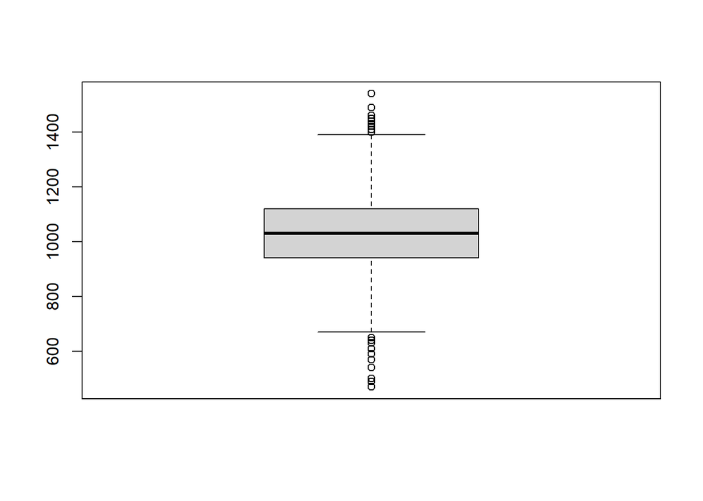

```r
#Box plot
boxplot(df.clean$sat)
```

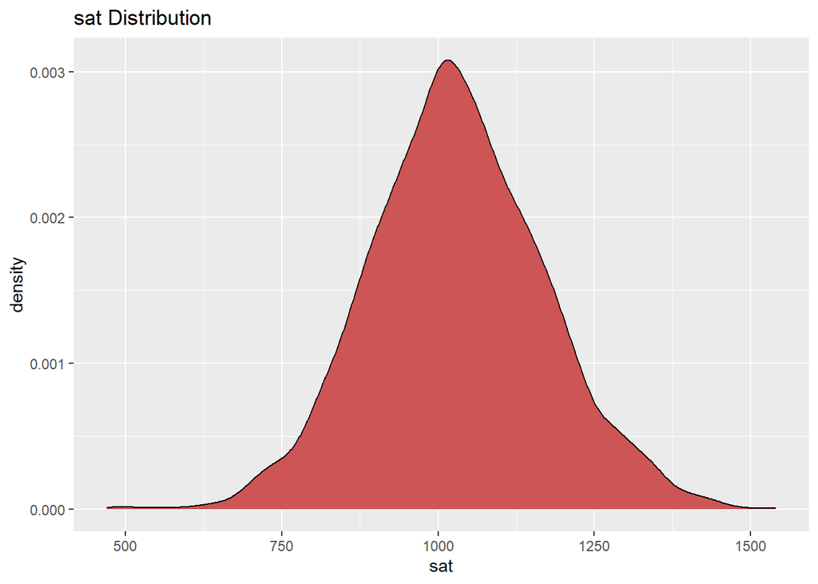

```r
#Density distribution
ggplot(df.clean, aes(x = sat)) +
  geom_density(fill = "indianred3") +
  labs(title = "sat Distribution")
```

```r
# #Set NA out of range
df.clean$sat[ 0 > df.clean$sat || df.clean$sat > 1600 ] <- NA
#Check if exist new NAs
sum(is.na(df.clean$sat))
```

```
## [1] 0
```

Un cop observada la distribució de les dades i aplicar un filtre amb els rangs establerts, podem veure que no hi havia cap valor fora d’aquestes, ja no hi ha cap valor NA.

## 4.2 hsize

Elaborem una anàlisi de la distribució de les dades. Observem que hi ha molts valors atípics (169), tot i això, no es canvien, ja que no es consideren valors anòmals.

```r
#Range values
summary(df.clean$hsize)
```

```
##    Min. 1st Qu.  Median    Mean 3rd Qu.    Max.
##    0.03    1.65    2.51    2.80    3.68    9.40
```

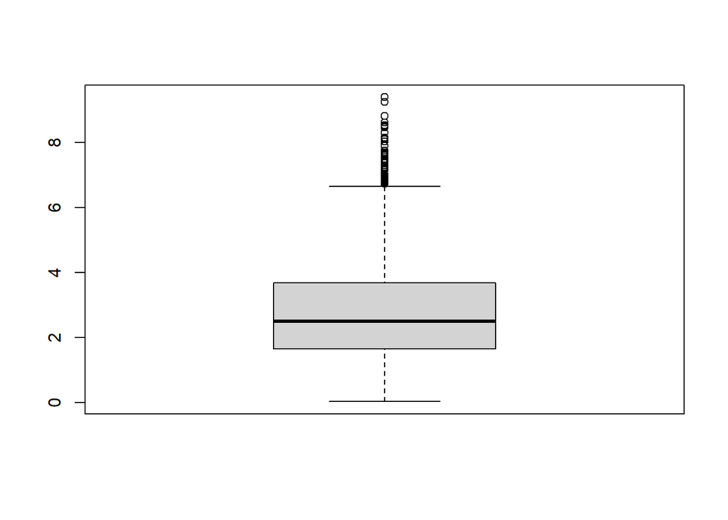

```r
#Box plot
boxplot(df.clean$hsize)
```

```r
hsize.out<-boxplot.stats(df.clean$hsize)$out
length(hsize.out)
```

```
## [1] 169
```

```r
sort(hsize.out)[1:169]
```

```
##   [1] 6.73 6.73 6.73 6.73 6.73 6.73 6.73 6.73 6.73 6.75 6.75 6.75 6.75 6.77 6.80
##  [16] 6.82 6.82 6.82 6.82 6.82 6.82 6.86 6.87 6.87 6.87 6.87 6.87 6.87 6.87 6.87
##  [31] 6.87 6.87 6.87 6.87 6.87 6.87 6.87 6.87 6.87 6.87 6.87 6.87 6.87 6.90 6.90
##  [46] 6.93 6.93 6.95 6.95 6.97 6.97 6.97 6.97 6.97 6.98 6.98 6.98 6.98 6.98 6.98
##  [61] 6.98 6.98 6.98 6.98 6.98 6.98 6.98 6.98 6.98 6.98 6.98 6.98 6.98 6.98 6.98
##  [76] 6.98 6.98 6.98 6.98 6.98 6.98 6.98 6.98 6.98 6.98 7.00 7.00 7.00 7.00 7.00
##  [91] 7.00 7.00 7.00 7.01 7.01 7.03 7.15 7.15 7.15 7.15 7.15 7.15 7.15 7.15 7.15
## [106] 7.15 7.15 7.15 7.15 7.15 7.15 7.15 7.15 7.15 7.15 7.15 7.15 7.15 7.15 7.15
## [121] 7.15 7.15 7.18 7.18 7.18 7.18 7.18 7.18 7.20 7.21 7.25 7.31 7.37 7.40 7.40
## [136] 7.42 7.45 7.45 7.45 7.46 7.49 7.50 7.60 7.64 7.68 7.71 7.71 7.71 7.71 7.76
## [151] 7.90 8.04 8.10 8.12 8.12 8.12 8.12 8.12 8.12 8.15 8.31 8.47 8.50 8.54 8.62
## [166] 8.82 8.82 9.26 9.40
```

```r
sum(df.clean$hsize>7)
```

```
## [1] 76
```

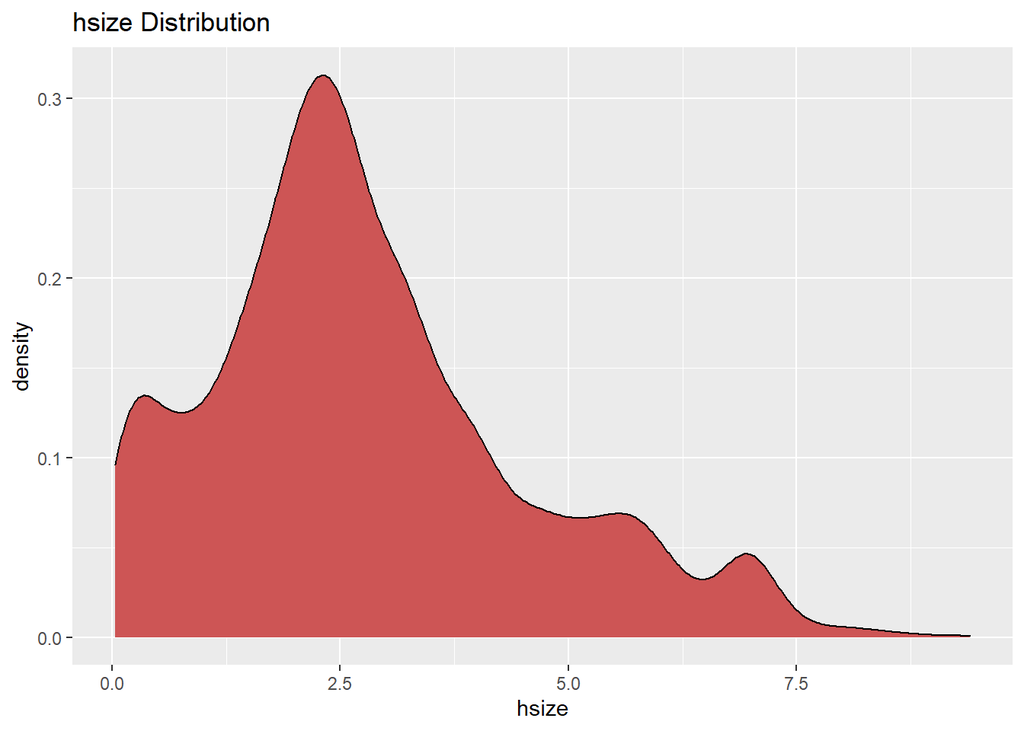

```r
#Density distribution
ggplot(df.clean, aes(x = hsize)) +
  geom_density(fill = "indianred3") +
  labs(title = "hsize Distribution")
```

# 5 Imputació de valors

El primer pas a realitzar, és saber quines variables tenen valors perduts per tal de realitzar una imputació posterior mitjançant el còmput dels veïns aplicant la distància de Gower.

```r
#Get num of NA values per each column
colSums(is.na(df.clean))
```

```
##     sat  tothrs   hsize  hsrank  hsperc  colgpa athlete  female   white   black
##       0       0       0       0       0      41       0       0       0       0
```

Observem que només hi ha valors perduts a la variable *‘colgpa’*. És per això que a continuació aplicarem la funció *‘kNN’* utilitzant les variables quantitatives del mateix gènere.

```r
#Obtenim les variables quantitatives
quant.variables <- which( colnames(df.clean) %in% c("sat","tothrs","hsize","hsrank","hsperc","colgpa"))
#Obtenim els indexs dels valors NA
idx <- which( is.na(df.clean$colgpa))

##fem idx
fem.idx <- which(is.na(df.clean$colgpa) & df.clean$female==TRUE); fem.idx
```

```
##  [1]  100  318  629 1172 1238 1319 1605 1866 1937 1975 2108 2530 2536 2721 2728
## [16] 3651 4015
```

```r
##men idx
mas.idx <- which(is.na(df.clean$colgpa) & df.clean$female==FALSE); mas.idx
```

```
##  [1]   40  343  490  500  846 1053 1226 1450 1888 2035 2184 2691 2879 3149 3196
## [16] 3495 3496 3523 3546 3660 3758 3798 3943 3998
```

```r
##compute fem new registers
new.fem<- kNN( df.clean[ df.clean$female==TRUE, quant.variables], variable="colgpa", k=11)
df.clean[fem.idx, quant.variables]
```

```
##       sat tothrs hsize hsrank hsperc colgpa
## 100  1120     49  0.10      1 10.000     NA
## 318  1050     12  3.70     30  8.108     NA
## 629   860     80  6.55    100 15.267     NA
## 1172  990     82  3.62     20  5.525     NA
## 1238 1060    120  4.39     32  7.289     NA
## 1319 1100     82  5.11     61 11.937     NA
## 1605 1030     77  5.70    108 18.947     NA
## 1866  810     84  2.14     10  4.673     NA
## 1937  830     46  4.50     97 21.556     NA
## 1975 1000     72  0.81     34 41.975     NA
## 2108  970     47  2.68     37 13.806     NA
## 2530  970     78  3.38      7  2.071     NA
## 2536  940     15  3.10     19  6.129     NA
## 2721  920    101  1.20     12 10.000     NA
## 2728  490    127  1.44     55 38.194     NA
## 3651  910     68  0.53     42 79.245     NA
## 4015  890     80  3.77    194 51.459     NA
```

```r
new.fem[new.fem$colgpa_imp==TRUE,]
```

```
##       sat tothrs hsize hsrank hsperc colgpa colgpa_imp
## 43   1120     49  0.10      1 10.000   3.31       TRUE
## 143  1050     12  3.70     30  8.108   2.60       TRUE
## 309   860     80  6.55    100 15.267   2.82       TRUE
## 552   990     82  3.62     20  5.525   2.81       TRUE
## 582  1060    120  4.39     32  7.289   3.15       TRUE
## 619  1100     82  5.11     61 11.937   2.55       TRUE
## 752  1030     77  5.70    108 18.947   2.59       TRUE
## 880   810     84  2.14     10  4.673   2.78       TRUE
## 909   830     46  4.50     97 21.556   2.37       TRUE
## 925  1000     72  0.81     34 41.975   2.19       TRUE
## 981   970     47  2.68     37 13.806   2.72       TRUE
## 1168  970     78  3.38      7  2.071   2.74       TRUE
## 1169  940     15  3.10     19  6.129   2.78       TRUE
## 1248  920    101  1.20     12 10.000   2.67       TRUE
## 1253  490    127  1.44     55 38.194   2.60       TRUE
## 1624  910     68  0.53     42 79.245   2.41       TRUE
## 1800  890     80  3.77    194 51.459   2.46       TRUE
```

```r
#set new values to df
df.clean[fem.idx,]$colgpa <- new.fem[new.fem$colgpa_imp==TRUE,]$colgpa

##compute men new registers
new.mas<- kNN( df.clean[ df.clean$female==FALSE, quant.variables], variable="colgpa", k=11)
df.clean[mas.idx, quant.variables]
```

```
##       sat tothrs hsize hsrank hsperc colgpa
## 40    940     19  1.85     41 22.162     NA
## 343  1100     43  7.45    218 29.262     NA
## 490  1090     95  4.72     67 14.195     NA
## 500   750     16  2.25     48 21.333     NA
## 846   970     39  2.21     77 34.842     NA
## 1053  900     17  1.54     44 28.571     NA
## 1226 1000     16  4.89     98 20.041     NA
## 1450  840     44  2.12     75 35.377     NA
## 1888 1040     16  0.83     23 27.711     NA
## 2035  990     78  0.72      3  4.167     NA
## 2184 1020     78  1.78     35 19.663     NA
## 2691 1260     50  7.00     47  6.714     NA
## 2879 1040    131  2.86     28  9.790     NA
## 3149  870     52  1.60     16 10.000     NA
## 3196 1070     14  2.34     36 15.385     NA
## 3495  910     13  4.89    145 29.652     NA
## 3496  910     40  4.77    125 26.205     NA
## 3523 1250     17  5.51     29  5.263     NA
## 3546  900     91  6.05     65 10.744     NA
## 3660  900     16  0.44     31 70.455     NA
## 3758 1160    120  1.72     11  6.395     NA
## 3798  930     44  2.92      6  2.055     NA
## 3943 1120     95  2.60     26 10.000     NA
## 3998  990     14  9.26    385 41.577     NA
```

```r
new.mas[new.mas$colgpa_imp==TRUE,]
```

```
##       sat tothrs hsize hsrank hsperc colgpa colgpa_imp
## 22    940     19  1.85     41 22.162   2.35       TRUE
## 187  1100     43  7.45    218 29.262   2.65       TRUE
## 249  1090     95  4.72     67 14.195   2.48       TRUE
## 254   750     16  2.25     48 21.333   2.18       TRUE
## 441   970     39  2.21     77 34.842   2.15       TRUE
## 545   900     17  1.54     44 28.571   2.26       TRUE
## 651  1000     16  4.89     98 20.041   2.72       TRUE
## 763   840     44  2.12     75 35.377   2.26       TRUE
## 1002 1040     16  0.83     23 27.711   2.43       TRUE
## 1085  990     78  0.72      3  4.167   2.81       TRUE
## 1170 1020     78  1.78     35 19.663   2.60       TRUE
## 1455 1260     50  7.00     47  6.714   3.46       TRUE
## 1547 1040    131  2.86     28  9.790   2.69       TRUE
## 1723  870     52  1.60     16 10.000   2.50       TRUE
## 1752 1070     14  2.34     36 15.385   2.50       TRUE
## 1931  910     13  4.89    145 29.652   2.68       TRUE
## 1932  910     40  4.77    125 26.205   2.35       TRUE
## 1948 1250     17  5.51     29  5.263   2.76       TRUE
## 1966  900     91  6.05     65 10.744   2.42       TRUE
## 2033  900     16  0.44     31 70.455   2.26       TRUE
## 2079 1160    120  1.72     11  6.395   3.23       TRUE
## 2103  930     44  2.92      6  2.055   2.74       TRUE
## 2180 1120     95  2.60     26 10.000   3.41       TRUE
## 2206  990     14  9.26    385 41.577   1.68       TRUE
```

```r
#set new values to df
df.clean[mas.idx,]$colgpa <- new.mas[new.mas$colgpa_imp==TRUE,]$colgpa

#Check that there is no NA values
colSums(is.na(df.clean))
```

```
##     sat  tothrs   hsize  hsrank  hsperc  colgpa athlete  female   white   black
##       0       0       0       0       0       0       0       0       0       0
```

# 6 Creació d’una nova variable

Hem de crear una nova variable anomenada *‘gpaletter’*. Per obtenir aquest valor hem de realitzar un mapping per intervals de la variable *‘colgpa’*.

```r
#Import library
library('mappings')
#Setting intervals
gpaletter_intervals <- c(0,1.50, 2.50, 3.50, 4.01)
#Creating mapping function
m <- cut_mapping(gpaletter_intervals, right=FALSE, to=c("D", "C", "B", "A"))
#print function
print(m)
```

```
## Mapping
##    mapsfrom mapsto
##     [0,1.5)      D
##   [1.5,2.5)      C
##   [2.5,3.5)      B
##  [3.5,4.01)      A
```

```r
#Applying function to generate new param
df.clean$gpaletter<- m(df.clean$colgpa)
#Checking new var
head(df.clean)
```

```
##    sat tothrs hsize hsrank hsperc colgpa athlete female white black gpaletter
## 1  920     43  0.10      4 40.000   2.04    TRUE   TRUE FALSE FALSE         C
## 2 1170     18  9.40    191 20.319   4.00   FALSE  FALSE  TRUE FALSE         A
## 3  810     14  1.19     42 35.294   1.78    TRUE  FALSE  TRUE FALSE         C
## 4  940     40  5.71    252 44.133   2.42   FALSE  FALSE  TRUE FALSE         C
## 5 1180     18  2.14     86 40.187   2.61   FALSE  FALSE  TRUE FALSE         B
## 6  980    114  2.68     41 15.299   3.03   FALSE   TRUE  TRUE FALSE         B
```

# 7 Estudi descriptiu

## 7.1 Estudi descriptiu de les variables qualitatives

En primer lloc es demanar representar de forma gràfica el percentatge d’atletes. En aquest observem que la gran majoria de la mostra no ho són.

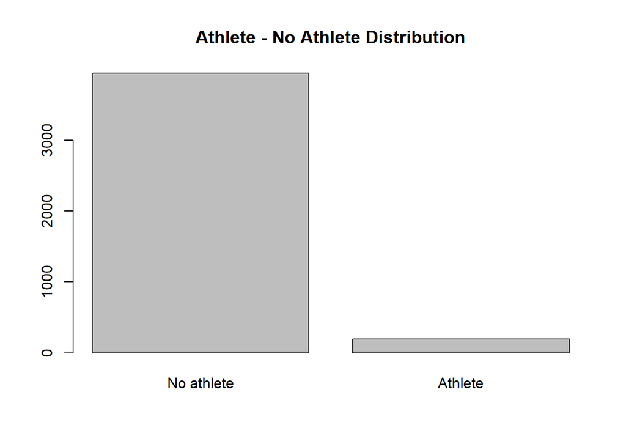

```r
athlete_table <- table(df.clean$athlete)
rownames(athlete_table) = c("No athlete", "Athlete")
barplot(athlete_table, main="Athlete - No Athlete Distribution")
```

A continuació, se’ns demana representar quin és el percentatge atletes tenint en compte el gènere de les persones. Observem que el percentatge d’atletes és major en els homes que en les dones.

```r
library('plyr')
library('dplyr')
#DF creation
df.femaleAthlete <- df.clean %>%
  group_by( female , athlete) %>%
  dplyr::summarise(counts = n())
df.femaleAthlete
```

```
## # A tibble: 4 x 3
## # Groups:   female [2]
##   female athlete counts
##   <fct>  <fct>    <int>
## 1 FALSE  FALSE     2128
## 2 FALSE  TRUE       149
## 3 TRUE   FALSE     1815
## 4 TRUE   TRUE        45
```

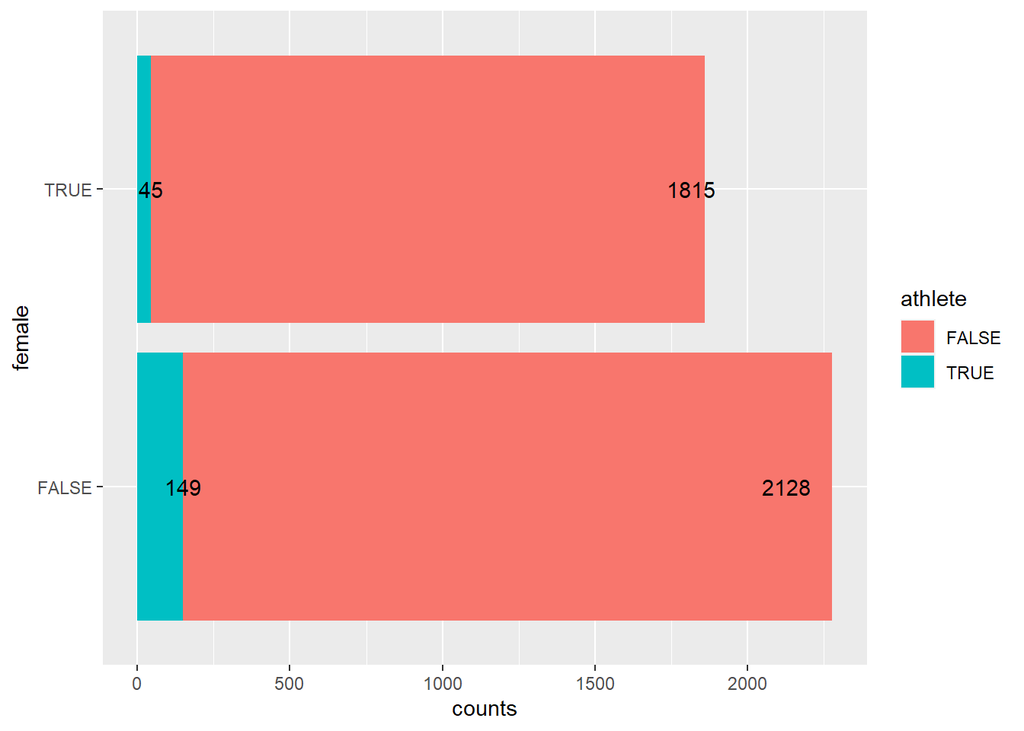

```r
#Plot
ggplot(df.femaleAthlete, aes(y = female, x = counts)) +
  geom_bar(
    aes(fill = athlete),
    stat = "identity", position = position_stack()
  ) + geom_text(aes(label=counts))
```

## 7.2 Estudi descriptiu de les variables quantitatives

Per a realitzar l’estudi descriptiu de les variables quantitatives realitzarem una taula amb diverses mesures.

```r
#index quantitative var
idx.quant <- c("sat","tothrs","hsize","hsrank","hsperc","colgpa")
#measures
mean <- as.vector(sapply(df.clean[,idx.quant], mean, na.rm=TRUE))
sd <- as.vector(sapply(df.clean[,idx.quant], sd, na.rm=TRUE))
median <- as.vector(sapply(df.clean[,idx.quant], median, na.rm=TRUE))
IQR <- as.vector(sapply(df.clean[,idx.quant],IQR, na.rm=TRUE))

#table creation
table.quant <- kable(data.frame(Variables=names(df.clean[idx.quant]),
                      Mean = mean,
                      StandardDeviation = sd,
                      Median = median,
                      IQR = IQR
                      ),
                digits=2, caption="Table")
table.quant
```

Table

| Variables | Mean | StandardDeviation | Median | IQR |
| --- | --- | --- | --- | --- |
| sat | 1030.33 | 139.40 | 1030.00 | 180.00 |
| tothrs | 52.83 | 35.33 | 47.00 | 63.00 |
| hsize | 2.80 | 1.74 | 2.51 | 2.03 |
| hsrank | 52.83 | 64.68 | 30.00 | 59.00 |
| hsperc | 19.24 | 16.57 | 14.60 | 21.28 |
| colgpa | 2.65 | 0.66 | 2.66 | 0.91 |

A continuació, presentarem gràfics per visualitzar la distribució de la variable *‘sat’* i *‘sat’* en funció del sexe.

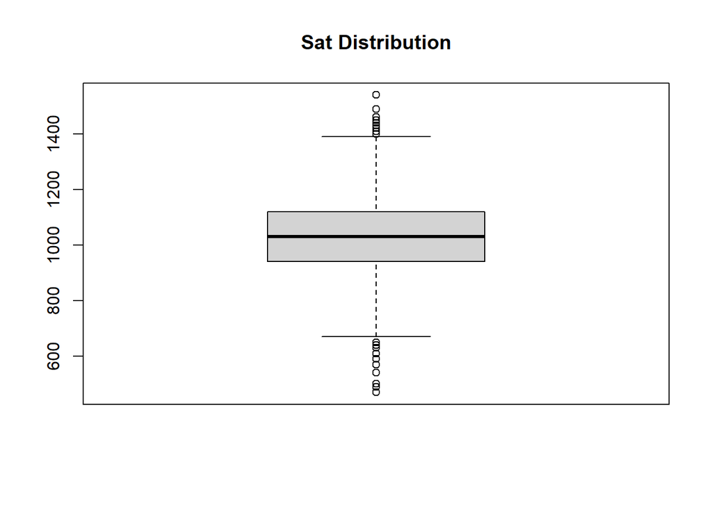

```r
#sat Box plot
boxplot(df.clean$sat, main="Sat Distribution")
```

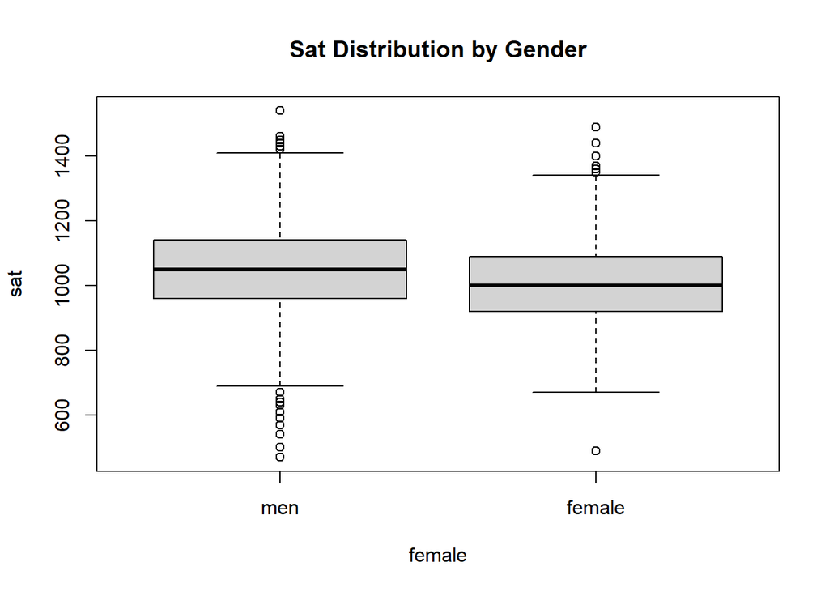

```r
#sat Box plot by gender
boxplot(data = df.clean, sat~female, main="Sat Distribution by Gender", names=c("men","female"))
```

# 8 Arxiu final

```r
write.csv(df,"gpa_clean.csv", row.names = TRUE)
```